# What is Statistical Learning?

You, Analyst

January 05, 2023

**Objectives:** In this notebook, we’ll use *toy data* to explore what statistical learning is. We’ll gain some insights into the types of models we’ll be building, the phenomena we’d like to understand/explain/predict, and the benefits as well as drawbacks of complicated models.

**Note:** This is another notebook where you’ll largely be running code that I’ve pre-built for you. You’ll be encouraged to make changes to the code and see how your changes impact the data we work with and the models being constructed. We’ll have a formal introduction to `R` in Weeks 2 - 4. You’ll be able to write all of this code on your own after that.

## Generating Toy Data

We’ll be using *synthetic* (fake) data in this notebook. Let’s generate some initial data now.

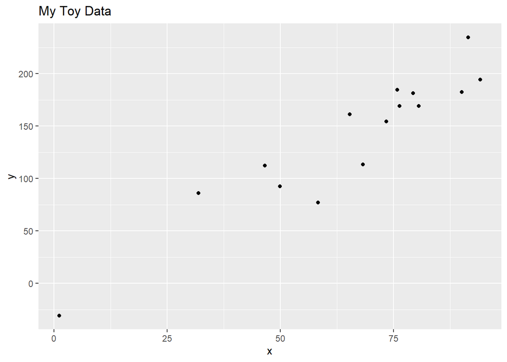

```r
num_points <- 15

set.seed(300)
x <- runif(n = num_points, min = 0, max = 100)
y <- 2*x + 8 + rnorm(num_points, mean = 0, sd = 20)

ggplot() +
  geom_point(aes(x = x, y = y)) +
  labs(title = "My Toy Data",
       x = "x",
       y = "y")
```

Now that we have our *toy data*, let’s draw the true association between `x` and `y` as a graph on top of our scatterplot.

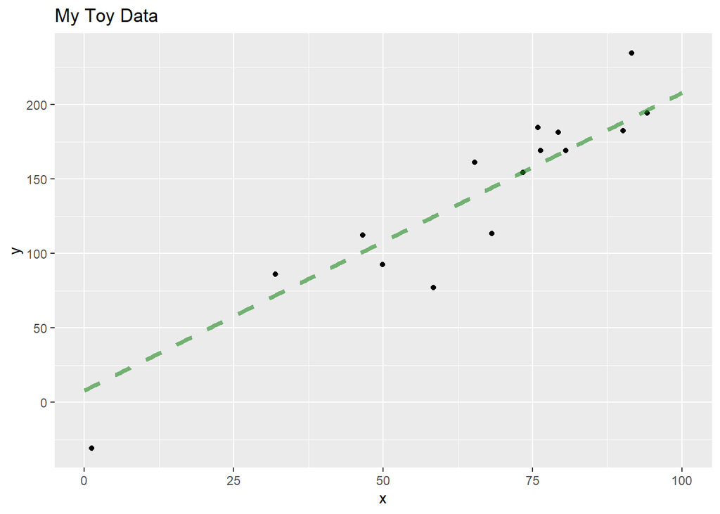

```r
x_plot <- seq(from = 0, to = 100, length.out = 250)
y_plot <- 2*x_plot + 8

ggplot() +
  geom_point(aes(x = x, y = y)) +
  geom_line(aes(x = x_plot, y = y_plot),
            color = "forestgreen",
            alpha = 0.6,
            lwd = 1.5,
            linetype = "dashed") +
  labs(title = "My Toy Data",
       x = "x",
       y = "y")
```

The *random noise* (generated using `rnrorm()`) in the data generating process prevents the linear model from exactly predicting each `y` value given the corresponding `x`.

## Building and Using a Model

We’ll pick apart the code being used below when we formally introduce `tidymodels` in Week 4. For now, let’s play with the code and see what types of models we can build and how well regression can pick up on the true association between our response, `y`, and our single predictor variable, `x`.

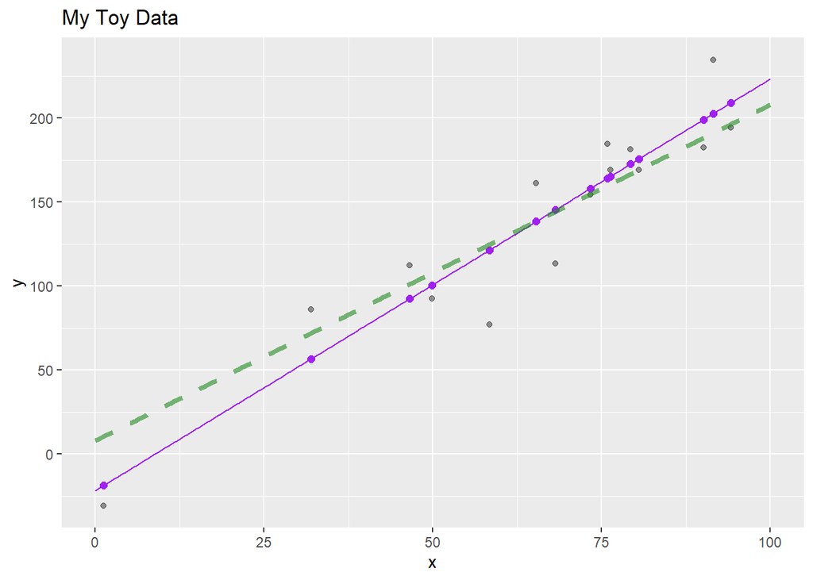

```r
toy_data <- tibble("x" = x, "y" = y)

lr_spec <- linear_reg() %>%
  set_engine("lm")

lr_rec <- recipe(y ~ x, data = toy_data)

#Recipe to allow for curvature
# lr_rec <- recipe(y ~ x, data = toy_data) %>%
#   step_poly(x, degree = 3, options = list(raw = TRUE))

lr_wf <- workflow() %>%
  add_model(lr_spec) %>%
  add_recipe(lr_rec)

lr_fit <- lr_wf %>%
  fit(toy_data)

preds <- lr_fit %>%
  predict(toy_data) %>%
  pull(.pred)
plot_preds <- lr_fit %>%
  predict(tibble("x" = x_plot)) %>%
  pull(.pred)

ggplot() +
  geom_point(aes(x = x, y = y),
             alpha = 0.4) +
  geom_point(aes(x = x, y = preds),
             color = "purple",
             size = 2) +
  geom_line(aes(x = x_plot, y = plot_preds),
            color = "purple") +
  geom_line(aes(x = x_plot, y = y_plot),
            color = "forestgreen",
            alpha = 0.6,
            lwd = 1.5,
            linetype = "dashed") +
  labs(title = "My Toy Data",
       x = "x",
       y = "y")
```

## My Model’s Errors

Now that we have predictions (`preds`) and the true responses (`y`), we can compute “prediction errors” for our models. These prediction errors are called *residuals*, and we compute them as the *observed response* minus the *predicted response*. That is, our `residuals = y - preds`.

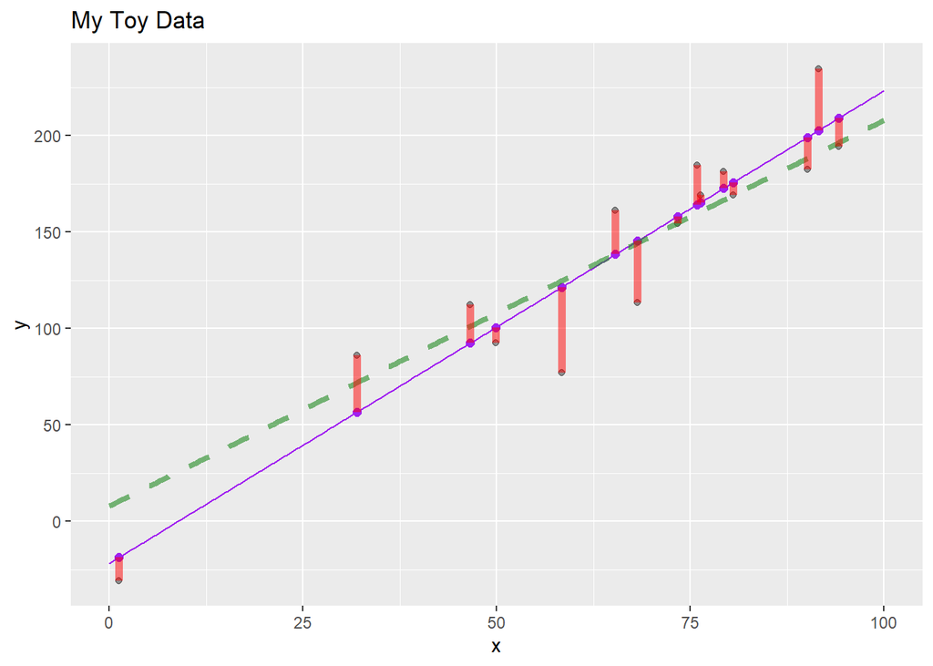

```r
ggplot() +
  geom_point(aes(x = x, y = y),
             alpha = 0.4) +
  geom_point(aes(x = x, y = preds),
             color = "purple",
             size = 2) +
  geom_line(aes(x = x_plot, y = plot_preds),
            color = "purple") +
  geom_line(aes(x = x_plot, y = y_plot),
            color = "forestgreen",
            alpha = 0.6,
            lwd = 1.5,
            linetype = "dashed") +
  geom_segment(aes(x = x, y = y, xend = x, yend = preds),
               color = "red",
               lwd = 2,
               alpha = 0.5) +
  labs(title = "My Toy Data",
       x = "x",
       y = "y")
```

**Regression Assumption 1:** A major assumption we make with regression models is that our *residuals* are normally distributed with a mean of 0 and a constant standard deviation. The *residuals* should also be uncorrelated with the magnitude of the response itself or with the magnitude of any predictor variables. Some residual plots are below:

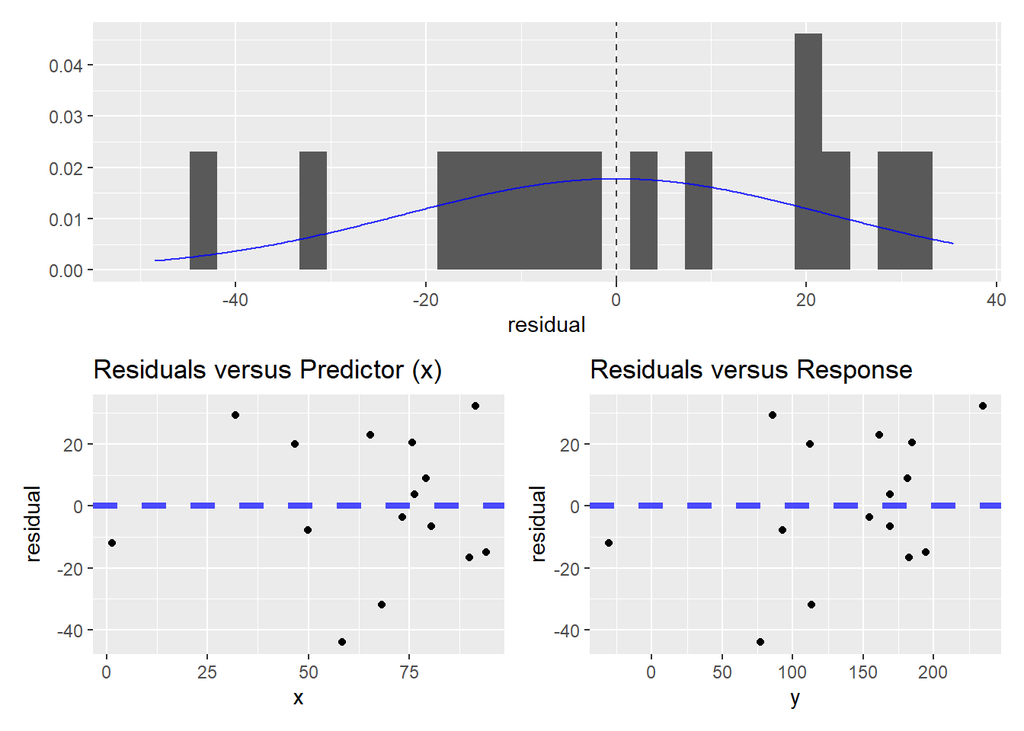

```r
residuals <- y - preds
mean_resid <- mean(residuals)
sd_resid <- sd(residuals)
x_dens_plot <- seq(1.1*min(residuals), 1.1*max(residuals), length.out = 500)

p1 <- ggplot() +
  geom_histogram(aes(x = residuals,
                     y = ..density..)) +
  geom_vline(xintercept = 0,
             linetype = "dashed",
             alpha = 0.75) +
  geom_line(aes(x = x_dens_plot,
                y = dnorm(x_dens_plot,
                          mean = mean_resid,
                          sd = sd_resid)),
            color = "blue",
            alpha = 0.8) +
  labs(x = "residual",
       y = "")

p2 <- ggplot() +
  geom_point(aes(x = x, y = residuals)) +
  geom_hline(yintercept = 0,
             color = "blue",
             linetype = "dashed",
             lwd = 1.5,
             alpha = 0.7) +
  labs(x = "x",
       y = "residual",
       title = "Residuals versus Predictor (x)")

p3 <- ggplot() +
  geom_point(aes(x = y, y = residuals)) +
  geom_hline(yintercept = 0,
             color = "blue",
             linetype = "dashed",
             lwd = 1.5,
             alpha = 0.7) +
  labs(x = "y",
       y = "residual",
       title = "Residuals versus Response")

p1 / (p2 + p3)
```

What do you notice?

## Questions

Let’s make some changes and re-run our analysis.